\( \newcommand{\bm}[1]{\boldsymbol{\mathbf{#1}}} \)

# 메타분석: R을 이용한 예제

서울시립대학교 통계학과 이용희

2019년 4월 23일

# 1 `R`과 메타분석 관련 패키지

메타분석을 위한 `R` 패키지는 `meta` 와 `metafor` 가 대표적이다. 두 패키지는 매우 유사하며 거의 비슷한 형식과 기능을 가지고 있다. 패키지는 `meta`는 교과서 Schwarzer, Carpenter, and Rücker (2015) 의 부록으로 나온 것이다. 패키지는 `metafor` 는 [홈페이지](http://www.metafor-project.org/doku.php) 에 다양한 예제가 소개되어 있어 유용하다.

여기서는 패키지는 `metafor`의 홈페이지에 나와있는 2개의 예제를 간단하게 소개하고 R을 이용한 기초적인 메타분석의 방법을 소개하고자 한다.

# 2 연속형변수

이 절에서 사용하는 자료는 패키지 `metafor` 에 주어진 Raudenbush (2009) 에 제시된 자료이다. 아래의 코드는 패키지는 `metafor` 의 [홈페이지](http://www.metafor-project.org/doku.php)에 실린 것을 그대로 사용하였다.

자료는 Raudenbush and Bryk (1985) 에서 이용한 19 개의 연구에 보고된 자료이며 연구 목적은 교사들의 관심이 학생들의 IQ 수준에 영향을 미치는 정도를 알아보는 것이다. 아 자료에서는 효과의 크기와 분산이 미리 계산되어 있다.

## 2.1 자료

먼저 패키지는 `metafor` 를 부른다.

```r
library(metafor)
```

분석에 이용할 자료 `dat` 를 생성한다.

자료 `dat`에서 중요한 변수는 다음과 같다.

- `yi`: 효과 크기의 추정치 ($\hat \theta_i$)
- `vi`: 효과 크기에 대한 추정치의 분산 ($\hat v^2_i$)

```r
dat <- dat.raudenbush1985
knitr::kable(dat, booktabs = TRUE, row.names = FALSE, caption = "Raudenbush (2009) data") %>%
    kable_styling(bootstrap_options = "striped", full_width = T)
```

Table 2.1: Raudenbush (2009) data

| study | author | year | weeks | setting | tester | n1i | n2i | yi | vi |
| --- | --- | --- | --- | --- | --- | --- | --- | --- | --- |
| 1 | Rosenthal et al. | 1974 | 2 | group | aware | 77 | 339 | 0.03 | 0.0156 |
| 2 | Conn et al. | 1968 | 21 | group | aware | 60 | 198 | 0.12 | 0.0216 |
| 3 | Jose & Cody | 1971 | 19 | group | aware | 72 | 72 | -0.14 | 0.0279 |
| 4 | Pellegrini & Hicks | 1972 | 0 | group | aware | 11 | 22 | 1.18 | 0.1391 |
| 5 | Pellegrini & Hicks | 1972 | 0 | group | blind | 11 | 22 | 0.26 | 0.1362 |
| 6 | Evans & Rosenthal | 1969 | 3 | group | aware | 129 | 348 | -0.06 | 0.0106 |
| 7 | Fielder et al. | 1971 | 17 | group | blind | 110 | 636 | -0.02 | 0.0106 |
| 8 | Claiborn | 1969 | 24 | group | aware | 26 | 99 | -0.32 | 0.0484 |
| 9 | Kester | 1969 | 0 | group | aware | 75 | 74 | 0.27 | 0.0269 |
| 10 | Maxwell | 1970 | 1 | indiv | blind | 32 | 32 | 0.80 | 0.0630 |
| 11 | Carter | 1970 | 0 | group | blind | 22 | 22 | 0.54 | 0.0912 |
| 12 | Flowers | 1966 | 0 | group | blind | 43 | 38 | 0.18 | 0.0497 |
| 13 | Keshock | 1970 | 1 | indiv | blind | 24 | 24 | -0.02 | 0.0835 |
| 14 | Henrikson | 1970 | 2 | indiv | blind | 19 | 32 | 0.23 | 0.0841 |
| 15 | Fine | 1972 | 17 | group | aware | 80 | 79 | -0.18 | 0.0253 |
| 16 | Grieger | 1970 | 5 | group | blind | 72 | 72 | -0.06 | 0.0279 |
| 17 | Rosenthal & Jacobson | 1968 | 1 | group | aware | 65 | 255 | 0.30 | 0.0193 |
| 18 | Fleming & Anttonen | 1971 | 2 | group | blind | 233 | 224 | 0.07 | 0.0088 |
| 19 | Ginsburg | 1970 | 7 | group | aware | 65 | 67 | -0.07 | 0.0303 |

## 2.2 고정효과 모형

고정효과 모형을 이용한 메타분석은 함수 `rma`를 이용하며 옵션으로 `method="FE"`를 지정한다.

```r
res.FE <- rma(yi, vi, data = dat, digits = 3, method = "FE")
res.FE
```

```
##
## Fixed-Effects Model (k = 19)
##
## Test for Heterogeneity:
## Q(df = 18) = 35.830, p-val = 0.007
##
## Model Results:
##
## estimate     se   zval   pval   ci.lb  ci.ub
##    0.060  0.036  1.655  0.098  -0.011  0.132  .
##
## ---
## Signif. codes:  0 '***' 0.001 '**' 0.01 '*' 0.05 '.' 0.1 ' ' 1
```

고정효과 모형을 적용한 결과는 다음과 같다.

- $\hat \theta_F = 0.060$
- $se(\hat \theta_F) = 0.036$
- $\theta_F$에 대한 95% 신뢰구간: $(-0.011, 0.132)$
- 가설검정 $H_0: \theta_F =0$에 대한 p-값 = 0.098
- $\hat Q = 35.830$

## 2.3 임의효과 모형

임의효과 모형을 이용한 메타분석은 함수 `rma`를 이용하며 옵션을 지정하지 않으면 디폴트(default)로 임의효과 모형을 적용한다.

```r
res.RE <- rma(yi, vi, data = dat, digits = 3)
res.RE
```

```
##
## Random-Effects Model (k = 19; tau^2 estimator: REML)
##
## tau^2 (estimated amount of total heterogeneity): 0.019 (SE = 0.016)
## tau (square root of estimated tau^2 value):      0.137
## I^2 (total heterogeneity / total variability):   41.86%
## H^2 (total variability / sampling variability):  1.72
##
## Test for Heterogeneity:
## Q(df = 18) = 35.830, p-val = 0.007
##
## Model Results:
##
## estimate     se   zval   pval   ci.lb  ci.ub
##    0.084  0.052  1.621  0.105  -0.018  0.185
##
## ---
## Signif. codes:  0 '***' 0.001 '**' 0.01 '*' 0.05 '.' 0.1 ' ' 1
```

임의효과 모형을 적용한 결과는 다음과 같다.

- $\hat \theta = 0.084$
- $se(\hat \theta_F) = 0.052$
- $\theta$에 대한 95% 신뢰구간: $(-0.018, 0.185)$
- 가설검정 $H_0: \theta_F =0$에 대한 p-값 = 0.105
- $\hat Q = 35.830$
- $\hat \tau^2 =0.019$
- $\hat I^2 = 41.86\%$
- $\hat H^2 = 1.72$

## 2.4 집단간의 변동 $\tau^2$을 추정하는 여러 가지 방법

집단간의 변동 $\tau^2$를 추정하는 방법은 다음과 같이 다양한 방법이 있다. 특별하게 지정하지 않으면 제한적인 최대가능도함수(Restriced Maximum Likelihood Estimation; `REML`)을 이용한다.

| Code | Estimator |
| --- | --- |
| `DL` | DerSimonian-Laird |
| `PM` | Paule-Mandel |
| `REML` | Restricted Maximum-Likelihood |
| `ML` | Maximum-likelihood |
| `HS` | Hunter-Schmidt |
| `SJ` | Sidik-Jonkman |
| `HE` | Hedges |
| `EB` | Empirical Bayes |

다음은 집단간의 변동 $\tau^2$를 추정할 때 Empirical Bayes를 이용한 예이다.

```r
rma(yi, vi, data = dat, digits = 3, method = "EB")
```

```
##
## Random-Effects Model (k = 19; tau^2 estimator: EB)
##
## tau^2 (estimated amount of total heterogeneity): 0.052 (SE = 0.029)
## tau (square root of estimated tau^2 value):      0.228
## I^2 (total heterogeneity / total variability):   66.44%
## H^2 (total variability / sampling variability):  2.98
##
## Test for Heterogeneity:
## Q(df = 18) = 35.830, p-val = 0.007
##
## Model Results:
##
## estimate     se   zval   pval   ci.lb  ci.ub
##    0.104  0.068  1.524  0.127  -0.030  0.238
##
## ---
## Signif. codes:  0 '***' 0.001 '**' 0.01 '*' 0.05 '.' 0.1 ' ' 1
```

## 2.5 숲그림

숲그림(forest plot)은 메타분석시 서로 다른 연구들의 효과크기 추정값과 신뢰구간을 비교하기 쉽게 보여주는 그림이다. 아래는 함수 `forest`를 사용하여 숲그림을 그린 예이다. `slab=paste(author, year, sep=", ")`은 각 연구의 저자와 년도를 묶어서 연구를 구별해주라는 옵션이다.

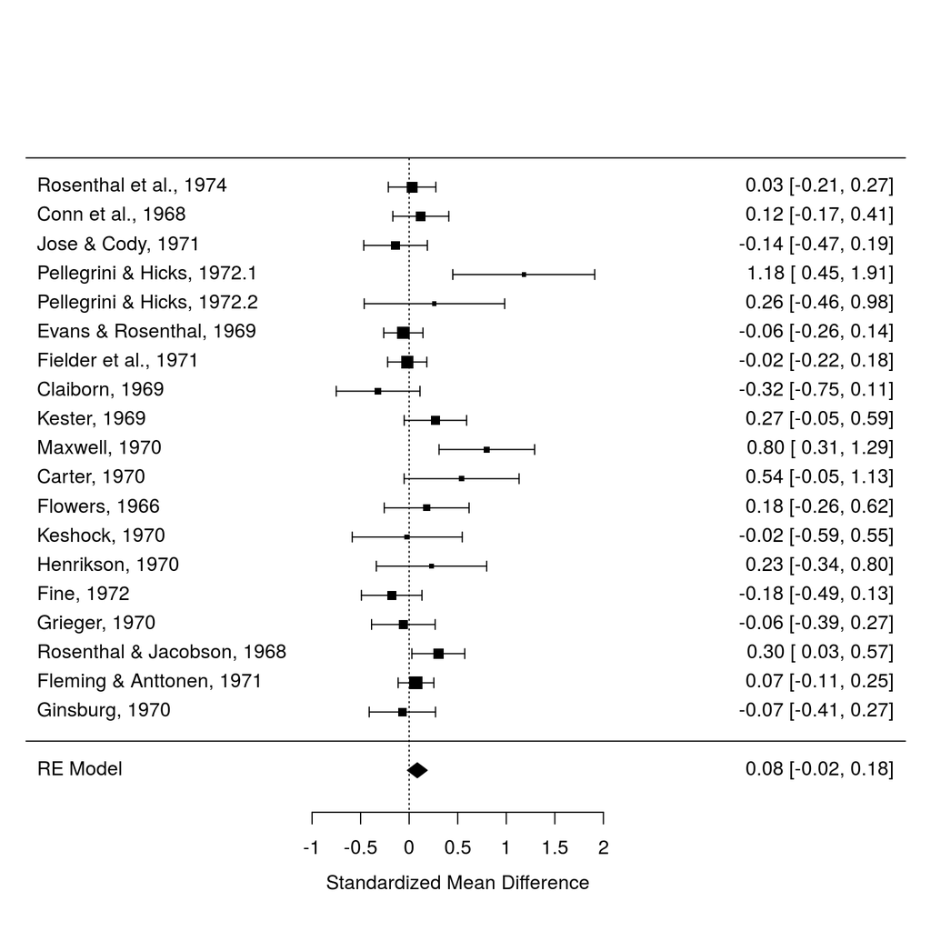

```r
res <- rma(yi, vi, data = dat, digits = 3, slab = paste(author, year, sep = ", "))
forest(res)
```

## 2.6 깔때기 그림

깔때기 그림(funnel plot)은 연구의 효과크기와 그 표준편차의 산포도를 보여주는 그림이다. 수직선은 메타분석의 추정량($\hat \theta = 0.084$)이며 삼각형의 두 변은 y축의 표준오차 값에 1.96을 곱한 크기를 죄우로 벌려준 값이다

$$(\hat \theta-1.96se, \hat \theta+1.96se)$$
.

깔때기 밖에 있는 연구들은 일종의 편향(publication bias..etc)를 가진다고 예상할 수 있다.

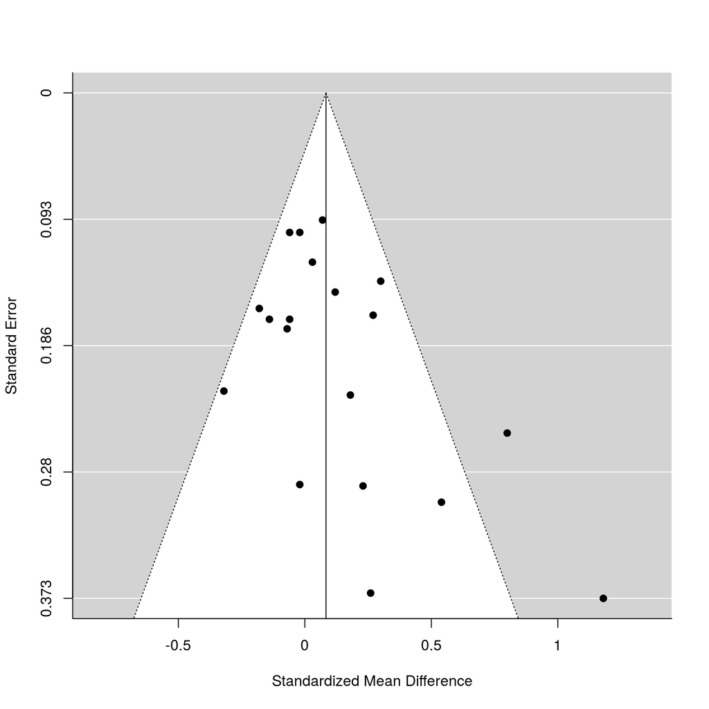

```r
funnel(res)
```

# 3 이항변수의 메타분석

이항변수, 즉 반응의 결과가 두 개의 항목(성공/실패, 유병/무병 등)으로 결과가 나타나는 연구에서는 성공 비율의 비교가 주 목적이다. 비율의 비교는 다음과 같은 다양한 측도가 있다.

- 비율의 차이 (difference in proportions; `RD`)
  $$\theta = p_t-p_c$$
- 상대위험 또는 로그 상대위험 (relative risk, risk ratio; `RR` )
  $$\theta = p_t/p_c$$
- 오즈비 또는 로그 오즈비 ( odd ratio; `OR`)
  $$\theta = \frac{p_t(1-p_c)}{p_c(1-p_t)}$$

비율을 비교하는 연구의 결과는 다음과 같은 2x2 분할표(contingency table)로 요약이 가능하다.

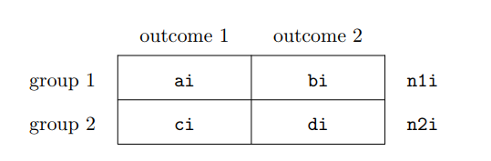

Figure 3.1: 2 x 2 contingency table

위에서 제시한 비율의 비교를 위한 세 가지 측도는 2x2 분할표에서 다음과 같이 계산한다.

- `RD`: `(ai/n1i) - (ci/n2i)`
- `RR`: `log ( (ai/n1i)/(ci/n2i) )`
- `OR`: `log ( (ai*di)/(bi*ci) )`

각 연구의 결과가 2x2 분할표로 주어진 경우 메타분석을 수행하는 예제를 고려해보자

## 3.1 자료

이용할 자료는 폐결핵(tuberculosis)의 예방을 위한 BCG 백신의 효과를 연구한 13 연구들의 결과이다 (Colditz et al. (1994)). 아래 나오는 `R` 프로그램은 패키지 `metafor`에 대한 설명 논문의 프로그램을 그대로 사용하였다 (Viechtbauer and Others (2010))

```r
data("dat.bcg", package = "metafor")
knitr::kable(dat.bcg, booktabs = TRUE, row.names = FALSE, caption = "BCG data") %>% kable_styling(bootstrap_options = "striped",
    full_width = T)
```

Table 3.1: BCG data

| trial | author | year | tpos | tneg | cpos | cneg | ablat | alloc |
| --- | --- | --- | --- | --- | --- | --- | --- | --- |
| 1 | Aronson | 1948 | 4 | 119 | 11 | 128 | 44 | random |
| 2 | Ferguson & Simes | 1949 | 6 | 300 | 29 | 274 | 55 | random |
| 3 | Rosenthal et al | 1960 | 3 | 228 | 11 | 209 | 42 | random |
| 4 | Hart & Sutherland | 1977 | 62 | 13536 | 248 | 12619 | 52 | random |
| 5 | Frimodt-Moller et al | 1973 | 33 | 5036 | 47 | 5761 | 13 | alternate |
| 6 | Stein & Aronson | 1953 | 180 | 1361 | 372 | 1079 | 44 | alternate |
| 7 | Vandiviere et al | 1973 | 8 | 2537 | 10 | 619 | 19 | random |
| 8 | TPT Madras | 1980 | 505 | 87886 | 499 | 87892 | 13 | random |
| 9 | Coetzee & Berjak | 1968 | 29 | 7470 | 45 | 7232 | 27 | random |
| 10 | Rosenthal et al | 1961 | 17 | 1699 | 65 | 1600 | 42 | systematic |
| 11 | Comstock et al | 1974 | 186 | 50448 | 141 | 27197 | 18 | systematic |
| 12 | Comstock & Webster | 1969 | 5 | 2493 | 3 | 2338 | 33 | systematic |
| 13 | Comstock et al | 1976 | 27 | 16886 | 29 | 17825 | 33 | systematic |

데이터 `dat.bcg` 에서 분할표에 대응하는 변수는 다음과 같다.

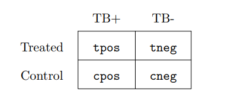

Figure 3.2: BCG data for 2 x 2 contingency table

- `ai` = `tpos`
- `bi` = `tneg`
- `ci` = `cpos`
- `di` = `cneg`

## 3.2 효과의 크기와 분산 계산

함수 `escal`을 이용하면 효과의 크기와 분산을 계산할 수 있다. 아래 `R` 문장은 각 연구에 대하여 로그 상대위험(`measure = "RR"`)와 그 분산을 계산하는 명령이다.

```r
dat1 <- escalc(measure = "RR", ai = tpos, bi = tneg, ci = cpos, di = cneg, data = dat.bcg,
    append = TRUE)
```

## 3.3 임의효과 모형

```r
res1.RE <- rma(yi, vi, data = dat1, digits = 3)
res1.RE
```

```
##
## Random-Effects Model (k = 13; tau^2 estimator: REML)
##
## tau^2 (estimated amount of total heterogeneity): 0.313 (SE = 0.166)
## tau (square root of estimated tau^2 value):      0.560
## I^2 (total heterogeneity / total variability):   92.22%
## H^2 (total variability / sampling variability):  12.86
##
## Test for Heterogeneity:
## Q(df = 12) = 152.233, p-val < .001
##
## Model Results:
##
## estimate     se    zval   pval   ci.lb   ci.ub
##   -0.715  0.180  -3.974  <.001  -1.067  -0.362  ***
##
## ---
## Signif. codes:  0 '***' 0.001 '**' 0.01 '*' 0.05 '.' 0.1 ' ' 1
```

## 3.4 숲그림

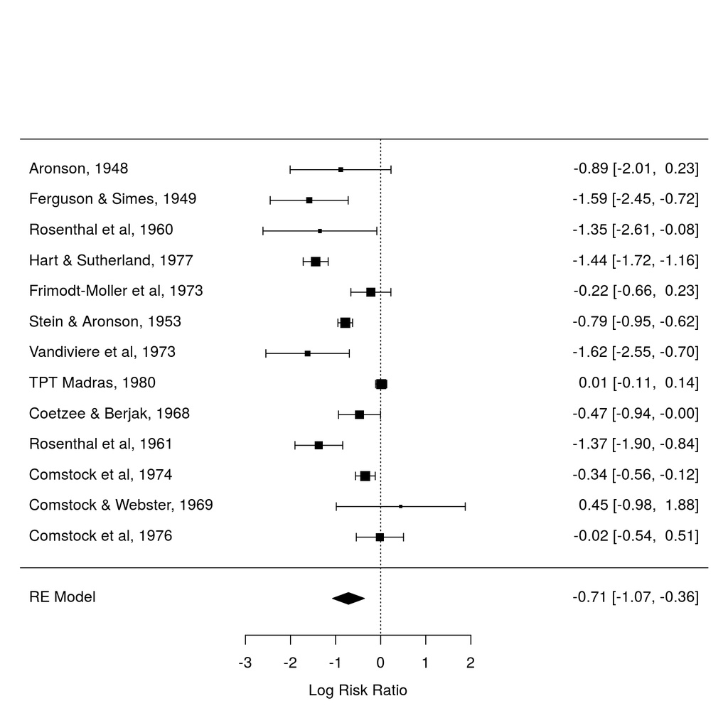

```r
res1 <- rma(yi, vi, data = dat1, digits = 3, slab = paste(author, year, sep = ", "))
forest(res1)
```

## 3.5 깔때기 그림

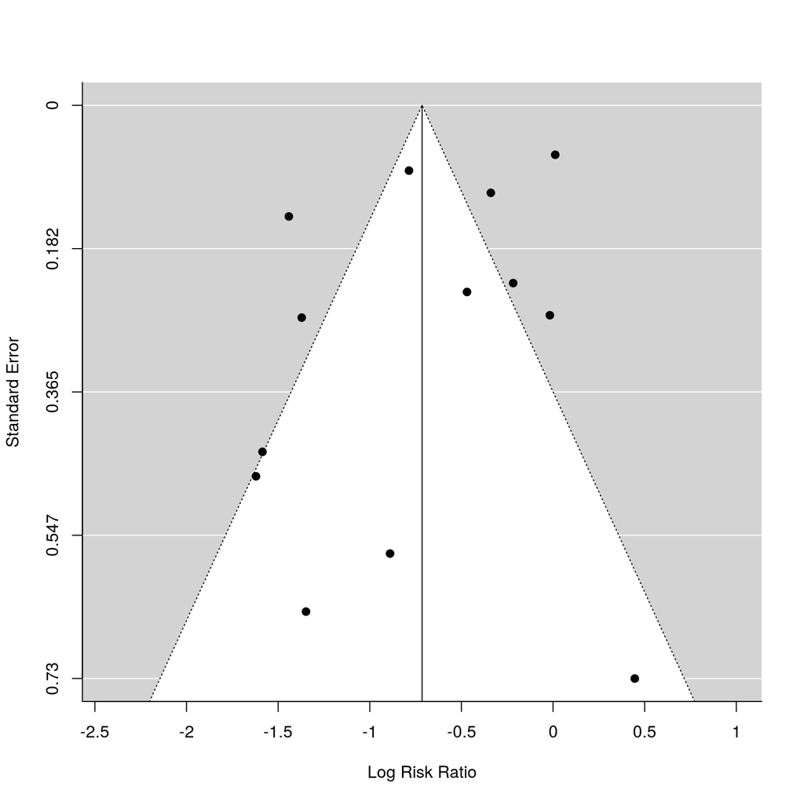

```r
funnel(res1)
```

# References

Colditz, G A, T F Brewer, C S Berkey, M E Wilson, E Burdick, H V Fineberg, and F Mosteller. 1994. “Efficacy of BCG Vaccine in the Prevention of Tuberculosis. Meta-Analysis of the Published Literature.” *JAMA* 271 (9). jamanetwork.com: 698–702.

Raudenbush, Stephen W. 2009. “Analyzing Effect Sizes: Random-Effects Models.” *The Handbook of Research Synthesis and Meta-Analysis* 2. books.google.com: 295–316.

Raudenbush, Stephen W, and Anthony S Bryk. 1985. “Empirical Bayes Meta-Analysis.” *J. Educ. Behav. Stat.* 10 (2). American Educational Research Association: 75–98.

Schwarzer, Guido, James R Carpenter, and Gerta Rücker. 2015. *Meta-Analysis with R*. Springer, Cham.

Viechtbauer, Wolfgang, and Others. 2010. “Conducting Meta-Analyses in R with the Metafor Package.” *J. Stat. Softw.* 36 (3). brieger.esalq.usp.br: 1–48.